# pandas

- Python modue used for data processing

```python
# Importing the pandas module as pd(pd stands for pandas)

import pandas as pd
import numpy as np # numpy for some additional computations and functions
```

```python
# function used to check the version of pandas we are using

pd.__version__
```

```
'1.2.4'
```

## Data types used in pandas

- 1. Series - one dimensional array used to store various values such as int, float, string, char etc.,.which is accessed by index.
- 1. Dataframe - two dimensional array used to store series. Since it is two dimensional it can be accessed by both row and column index.

## Series

### Manipulating

```python
# creating a series with list

lis = [1,2,3,4,5]
series = pd.Series(lis)
series
```

```
0    1
1    2
2    3
3    4
4    5
dtype: int64
```

- Here the .Series() function is used to create series object with index from (0- ...). Index is used to acess the values

```python
index = ['a','b','c','d','e']
series_1 = pd.Series(lis,index = index)
series_1
```

```
a    1
b    2
c    3
d    4
e    5
dtype: int64
```

- Here we sets the index manually wih the help of a list.

```python
list_np = np.random.randn(5) # creating  random array within the int value 5
series_np = pd.Series(list_np,index)
series_np
```

```
a    0.587303
b   -0.298542
c   -0.857714
d    1.632934
e   -2.396665
dtype: float64
```

- Here a random array was constructed and the indexes were also allocated manually.

```python
# Series created with the help of dictionary

dic = {'a':0,'b':1,'c':3,'d':4,'e':5}
series_dic = pd.Series(dic)
series_dic
```

```
a    0
b    1
c    3
d    4
e    5
dtype: int64
```

- when we use dictionary to create a series, its key is used to set index and its value is used to set the value for that key(index)

### Modifying

```python
print(series)
```

```
0    1
1    2
2    3
3    4
4    5
dtype: int64
```

```python
# we can modify the index of the series

print(series)
series.index=['a','b','c','d','e'] # the number indexes should be always equal to the number of values in the series
series
```

```
0    1
1    2
2    3
3    4
4    5
dtype: int64
```

```
a    1
b    2
c    3
d    4
e    5
dtype: int64
```

```python
# series slicing

series[1:4]
```

```
b    2
c    3
d    4
dtype: int64
```

```python
# combining two series

series_combine = series.append(series_dic)
series_combine
```

```
a    1
b    2
c    3
d    4
e    5
a    0
b    1
c    3
d    4
e    5
dtype: int64
```

```python
# removing any element from series by index with the help of drop()

series_combine.drop('e')

# since there were two values in the series with the same index 'e' both of them were deleted
```

```
a    1
b    2
c    3
d    4
a    0
b    1
c    3
d    4
dtype: int64
```

```python
series_combine
```

```
a    1
b    2
c    3
d    4
e    5
a    0
b    1
c    3
d    4
e    5
dtype: int64
```

- Here we can again see the index 'e' that is because with just executed the drop but didnt assigned it to the variable

### series_operations

```python
arr1 = [1,2,3,4,5]
arr2 = [0,6,7,8]

series_arr1 = pd.Series(arr1)
series_arr2 = pd.Series(arr2)

print(series_arr1)
print(series_arr2)
```

```
0    1
1    2
2    3
3    4
4    5
dtype: int64
0    0
1    6
2    7
3    8
dtype: int64
```

```python
series_arr1.add(series_arr2)

# here instead of error pandas gives NaN value, there is no values to perform add so it is showing NaN.
```

```
0     1.0
1     8.0
2    10.0
3    12.0
4     NaN
dtype: float64
```

```python
series_arr1.sub(series_arr2)
```

```
0    1.0
1   -4.0
2   -4.0
3   -4.0
4    NaN
dtype: float64
```

```python
series_arr1.mul(series_arr2)
```

```
0     0.0
1    12.0
2    21.0
3    32.0
4     NaN
dtype: float64
```

```python
series_arr1.div(series_arr2)
```

```
0         inf
1    0.333333
2    0.428571
3    0.500000
4         NaN
dtype: float64
```

```python
print(f'Median of {arr1}:',series_arr1.median())
print(f'Max of {arr1}:',series_arr1.max())
print(f'Min of {arr1}:',series_arr1.min())
```

```
Median of [1, 2, 3, 4, 5]: 3.0
Max of [1, 2, 3, 4, 5]: 5
Min of [1, 2, 3, 4, 5]: 1
```

## Dataframe

```python
index_date = pd.date_range('today',periods = 6)
index_date
```

```
DatetimeIndex(['2022-04-19 00:22:57.957078', '2022-04-20 00:22:57.957078',
               '2022-04-21 00:22:57.957078', '2022-04-22 00:22:57.957078',
               '2022-04-23 00:22:57.957078', '2022-04-24 00:22:57.957078'],
              dtype='datetime64[ns]', freq='D')
```

- To know more about data_range()

https://www.w3resource.com/pandas/date_range.php

```python
index_date = pd.date_range('today',periods = 6)
np_arr = np.random.randn(6,4)
column = ['a','b','c','d']
df_np_arr = pd.DataFrame(np_arr,index = index_date, columns = column)
df_np_arr
```

|  | a | b | c | d |
| --- | --- | --- | --- | --- |
| 2022-04-19 00:22:58.065659 | 1.501606 | -0.045258 | -0.420184 | -0.242329 |
| 2022-04-20 00:22:58.065659 | 0.116876 | 0.016327 | 1.650071 | 0.566629 |
| 2022-04-21 00:22:58.065659 | 0.576227 | 0.883448 | 0.926566 | -2.052874 |
| 2022-04-22 00:22:58.065659 | -0.765957 | -1.026251 | -0.041472 | -0.045334 |
| 2022-04-23 00:22:58.065659 | -1.307083 | 1.181933 | 0.130363 | -2.355210 |
| 2022-04-24 00:22:58.065659 | -0.019864 | 1.491984 | -0.627648 | -1.273195 |

```python
dfDic = {'name':['shyam','titus','abisha','achsah','jeyakani','andrea','prem','peter','bennat'],
         'age':[18,20,20,19,20,19,21,17,22],
         'career_field':['engineering','medical','medical','medical','medical','arts and science','teaching','computer science','medicine']}
dfDic

dfDic_index = ['a','b','c','d','e','f','g','h','i']

df_dic = pd.DataFrame(dfDic,index = dfDic_index)
df_dic
```

|  | name | age | career_field |
| --- | --- | --- | --- |
| a | shyam | 18 | engineering |
| b | titus | 20 | medical |
| c | abisha | 20 | medical |
| d | achsah | 19 | medical |
| e | jeyakani | 20 | medical |
| f | andrea | 19 | arts and science |
| g | prem | 21 | teaching |
| h | peter | 17 | computer science |
| i | bennat | 22 | medicine |

```python
# dataframe.columns is used to see the column values of the dataframe

df_dic.columns
```

```
Index(['name', 'age', 'career_field'], dtype='object')
```

```python
df_dic.index
```

```
Index(['a', 'b', 'c', 'd', 'e', 'f', 'g', 'h', 'i'], dtype='object')
```

Here both 'index' and 'column' are attributes of a dataframe used to see the index and column values

```python
df_dic.head(6)
```

|  | name | age | career_field |
| --- | --- | --- | --- |
| a | shyam | 18 | engineering |
| b | titus | 20 | medical |
| c | abisha | 20 | medical |
| d | achsah | 19 | medical |
| e | jeyakani | 20 | medical |
| f | andrea | 19 | arts and science |

Used to see the first 6 values of the dataframe. Default this head() function gives first 5 values

```python
df_dic.tail()
```

|  | name | age | career_field |
| --- | --- | --- | --- |
| e | jeyakani | 20 | medical |
| f | andrea | 19 | arts and science |
| g | prem | 21 | teaching |
| h | peter | 17 | computer science |
| i | bennat | 22 | medicine |

tail() is used to perform the same function as head but for the last values of dataframe

```python
# used to see the statistics overview of our data
df_dic.describe()
```

|  | age |
| --- | --- |
| count | 9.000000 |
| mean | 19.555556 |
| std | 1.509231 |
| min | 17.000000 |
| 25% | 19.000000 |
| 50% | 20.000000 |
| 75% | 20.000000 |
| max | 22.000000 |

### Data manipulation

```python
df_dic
```

|  | name | age | career_field |
| --- | --- | --- | --- |
| a | shyam | 18 | engineering |
| b | titus | 20 | medical |
| c | abisha | 20 | medical |
| d | achsah | 19 | medical |
| e | jeyakani | 20 | medical |
| f | andrea | 19 | arts and science |
| g | prem | 21 | teaching |
| h | peter | 17 | computer science |
| i | bennat | 22 | medicine |

```python
# used to transpose our dataframe

df_dic.T
```

|  | a | b | c | d | e | f | g | h | i |
| --- | --- | --- | --- | --- | --- | --- | --- | --- | --- |
| name | shyam | titus | abisha | achsah | jeyakani | andrea | prem | peter | bennat |
| age | 18 | 20 | 20 | 19 | 20 | 19 | 21 | 17 | 22 |
| career_field | engineering | medical | medical | medical | medical | arts and science | teaching | computer science | medicine |

```python
# sort_values() is used to sort out dataframe based on the argument passed

df_dic.sort_values(by = 'age')
```

|  | name | age | career_field |
| --- | --- | --- | --- |
| h | peter | 17 | computer science |
| a | shyam | 18 | engineering |
| d | achsah | 19 | medical |
| f | andrea | 19 | arts and science |
| b | titus | 20 | medical |
| c | abisha | 20 | medical |
| e | jeyakani | 20 | medical |
| g | prem | 21 | teaching |
| i | bennat | 22 | medicine |

- syntax of sort_values()------> Default setup

DataFrame.sort_values(by, axis=0, ascending=True, inplace=False, kind='quicksort', na_position='last', ignore_index=False, key=None)

```python
# sorting in descending order

df_dic.sort_values(by = 'age',ascending = False)
```

|  | name | age | career_field |
| --- | --- | --- | --- |
| i | bennat | 22 | medicine |
| g | prem | 21 | teaching |
| b | titus | 20 | medical |
| c | abisha | 20 | medical |
| e | jeyakani | 20 | medical |
| d | achsah | 19 | medical |
| f | andrea | 19 | arts and science |
| a | shyam | 18 | engineering |
| h | peter | 17 | computer science |

```python
# we can also sort character values

df_dic.sort_values(by = 'name')
```

|  | name | age | career_field |
| --- | --- | --- | --- |
| c | abisha | 20 | medical |
| d | achsah | 19 | medical |
| f | andrea | 19 | arts and science |
| i | bennat | 22 | medicine |
| e | jeyakani | 20 | medical |
| h | peter | 17 | computer science |
| g | prem | 21 | teaching |
| a | shyam | 18 | engineering |
| b | titus | 20 | medical |

```python
# dataframe slicing

df_dic[1:4]
```

|  | name | age | career_field |
| --- | --- | --- | --- |
| b | titus | 20 | medical |
| c | abisha | 20 | medical |
| d | achsah | 19 | medical |

```python
df_dic['a':'d']
```

|  | name | age | career_field |
| --- | --- | --- | --- |
| a | shyam | 18 | engineering |
| b | titus | 20 | medical |
| c | abisha | 20 | medical |
| d | achsah | 19 | medical |

```python
# iloc[] is also identical to slicing, slicing the list dataframe with the help of its integer index value

df_dic.iloc[1:4]
```

|  | name | age | career_field |
| --- | --- | --- | --- |
| b | titus | 20 | medical |
| c | abisha | 20 | medical |
| d | achsah | 19 | medical |

```python
# copy() function is used to copy the df

df_dic_copy = df_dic.copy()
df_dic_copy
```

|  | name | age | career_field |
| --- | --- | --- | --- |
| a | shyam | 18 | engineering |
| b | titus | 20 | medical |
| c | abisha | 20 | medical |
| d | achsah | 19 | medical |
| e | jeyakani | 20 | medical |
| f | andrea | 19 | arts and science |
| g | prem | 21 | teaching |
| h | peter | 17 | computer science |
| i | bennat | 22 | medicine |

```python
# isnull() is used to check whether our dataframe have any null values

df_dic.isnull()
```

|  | name | age | career_field |
| --- | --- | --- | --- |
| a | False | False | False |
| b | False | False | False |
| c | False | False | False |
| d | False | False | False |
| e | False | False | False |
| f | False | False | False |
| g | False | False | False |
| h | False | False | False |
| i | False | False | False |

```python
df_dic
```

|  | name | age | career_field |
| --- | --- | --- | --- |
| a | shyam | 18 | engineering |
| b | titus | 20 | medical |
| c | abisha | 20 | medical |
| d | achsah | 19 | medical |
| e | jeyakani | 20 | medical |
| f | andrea | 19 | arts and science |
| g | prem | 21 | teaching |
| h | peter | 17 | computer science |
| i | bennat | 22 | medicine |

```python
# loc() is also used to access the values

df_dic.loc['a']
```

```
name                  shyam
age                      18
career_field    engineering
Name: a, dtype: object
```

```python
df_dic.loc['a','name']
```

```
'shyam'
```

```python
# by loc we can also replace the values

df_dic.loc['a','name']='shyam joshuva'
```

```python
df_dic
```

|  | name | age | career_field |
| --- | --- | --- | --- |
| a | shyam joshuva | 18 | engineering |
| b | titus | 20 | medical |
| c | abisha | 20 | medical |
| d | achsah | 19 | medical |
| e | jeyakani | 20 | medical |
| f | andrea | 19 | arts and science |
| g | prem | 21 | teaching |
| h | peter | 17 | computer science |
| i | bennat | 22 | medicine |

```python
df_dic.mean()
```

```
age    19.555556
dtype: float64
```

- The above code gives the mean of age in the dataframe because it is the only mathematical value in the dataframe

```python
# we can also specifically select any particular column

df_dic['age'].mean()
```

```
19.555555555555557
```

```python
df_dic['age'].sum()
```

```
176
```

```python
df_dic.sum()
```

```
name            shyam joshuvatitusabishaachsahjeyakaniandreapr...
age                                                           176
career_field    engineeringmedicalmedicalmedicalmedicalarts an...
dtype: object
```

```python
series_string = df_dic['name']
series_string
```

```
a    shyam joshuva
b            titus
c           abisha
d           achsah
e         jeyakani
f           andrea
g             prem
h            peter
i           bennat
Name: name, dtype: object
```

```python
series_string.str.upper()
```

```
a    SHYAM JOSHUVA
b            TITUS
c           ABISHA
d           ACHSAH
e         JEYAKANI
f           ANDREA
g             PREM
h            PETER
i           BENNAT
Name: name, dtype: object
```

```python
series_string.str.lower()
```

```
a    shyam joshuva
b            titus
c           abisha
d           achsah
e         jeyakani
f           andrea
g             prem
h            peter
i           bennat
Name: name, dtype: object
```

### Operations on Dataframe missing values

```python
df_dic
```

|  | name | age | career_field |
| --- | --- | --- | --- |
| a | shyam joshuva | 18 | engineering |
| b | titus | 20 | medical |
| c | abisha | 20 | medical |
| d | achsah | 19 | medical |
| e | jeyakani | 20 | medical |
| f | andrea | 19 | arts and science |
| g | prem | 21 | teaching |
| h | peter | 17 | computer science |
| i | bennat | 22 | medicine |

```python
df_dic_copy
```

|  | name | age | career_field |
| --- | --- | --- | --- |
| a | shyam | 18 | engineering |
| b | titus | 20 | medical |
| c | abisha | 20 | medical |
| d | achsah | 19 | medical |
| e | jeyakani | 20 | medical |
| f | andrea | 19 | arts and science |
| g | prem | 21 | teaching |
| h | peter | 17 | computer science |
| i | bennat | 22 | medicine |

```python
df_dic_copy_1 = df_dic_copy.copy()
df_dic_copy_1
```

|  | name | age | career_field |
| --- | --- | --- | --- |
| a | shyam | 18 | engineering |
| b | titus | 20 | medical |
| c | abisha | 20 | medical |
| d | achsah | 19 | medical |
| e | jeyakani | 20 | medical |
| f | andrea | 19 | arts and science |
| g | prem | 21 | teaching |
| h | peter | 17 | computer science |
| i | bennat | 22 | medicine |

```python
df_dic_copy_1.loc['c','age']=np.nan
df_dic_copy_1.loc['a','age']=np.nan
```

```python
df_dic_copy_1
```

|  | name | age | career_field |
| --- | --- | --- | --- |
| a | shyam | NaN | engineering |
| b | titus | 20.0 | medical |
| c | abisha | NaN | medical |
| d | achsah | 19.0 | medical |
| e | jeyakani | 20.0 | medical |
| f | andrea | 19.0 | arts and science |
| g | prem | 21.0 | teaching |
| h | peter | 17.0 | computer science |
| i | bennat | 22.0 | medicine |

```python
# filna() is used to fill or add values in place of nan, here 'inplace' assigns the change we do to the dataframe

df_dic_copy_1['age'].fillna(20,inplace=True)
```

```python
df_dic_copy_1
```

|  | name | age | career_field |
| --- | --- | --- | --- |
| a | shyam | 20.0 | engineering |
| b | titus | 20.0 | medical |
| c | abisha | 20.0 | medical |
| d | achsah | 19.0 | medical |
| e | jeyakani | 20.0 | medical |
| f | andrea | 19.0 | arts and science |
| g | prem | 21.0 | teaching |
| h | peter | 17.0 | computer science |
| i | bennat | 22.0 | medicine |

```python
df_dic_copy_2 = df_dic_copy.copy()
df_dic_copy_2
```

|  | name | age | career_field |
| --- | --- | --- | --- |
| a | shyam | 18 | engineering |
| b | titus | 20 | medical |
| c | abisha | 20 | medical |
| d | achsah | 19 | medical |
| e | jeyakani | 20 | medical |
| f | andrea | 19 | arts and science |
| g | prem | 21 | teaching |
| h | peter | 17 | computer science |
| i | bennat | 22 | medicine |

```python
df_dic_copy_2.loc['a','name']=np.nan
df_dic_copy_2.loc['g','name']=np.nan
```

```python
df_dic_copy_2
```

|  | name | age | career_field |
| --- | --- | --- | --- |
| a | NaN | 18 | engineering |
| b | titus | 20 | medical |
| c | abisha | 20 | medical |
| d | achsah | 19 | medical |
| e | jeyakani | 20 | medical |
| f | andrea | 19 | arts and science |
| g | NaN | 21 | teaching |
| h | peter | 17 | computer science |
| i | bennat | 22 | medicine |

```python
# dropna() is used to drop the nan vaues from our dataframe

df_dic_copy_2.dropna()
```

|  | name | age | career_field |
| --- | --- | --- | --- |
| b | titus | 20 | medical |
| c | abisha | 20 | medical |
| d | achsah | 19 | medical |
| e | jeyakani | 20 | medical |
| f | andrea | 19 | arts and science |
| h | peter | 17 | computer science |
| i | bennat | 22 | medicine |

```python
df_dic_copy_2
```

|  | name | age | career_field |
| --- | --- | --- | --- |
| a | NaN | 18 | engineering |
| b | titus | 20 | medical |
| c | abisha | 20 | medical |
| d | achsah | 19 | medical |
| e | jeyakani | 20 | medical |
| f | andrea | 19 | arts and science |
| g | NaN | 21 | teaching |
| h | peter | 17 | computer science |
| i | bennat | 22 | medicine |

```python
df_dic_copy_2.dropna(inplace=True)
```

```python
df_dic_copy_2
```

|  | name | age | career_field |
| --- | --- | --- | --- |
| b | titus | 20 | medical |
| c | abisha | 20 | medical |
| d | achsah | 19 | medical |
| e | jeyakani | 20 | medical |
| f | andrea | 19 | arts and science |
| h | peter | 17 | computer science |
| i | bennat | 22 | medicine |

### Dataframe file operations

```python
df_dic
```

|  | name | age | career_field |
| --- | --- | --- | --- |
| a | shyam joshuva | 18 | engineering |
| b | titus | 20 | medical |
| c | abisha | 20 | medical |
| d | achsah | 19 | medical |
| e | jeyakani | 20 | medical |
| f | andrea | 19 | arts and science |
| g | prem | 21 | teaching |
| h | peter | 17 | computer science |
| i | bennat | 22 | medicine |

```python
df_dic.to_csv('friends.csv',index=False)
```

- The above function creates our dataframe into a csv file

```python
# To read any csv file the syntax is ---->  pd.read_csv(FILE NAME WITH EXTENSION OF FORMAT USED)

df_friends_csv= pd.read_csv('friends.csv')
df_friends_csv
```

|  | name | age | career_field |
| --- | --- | --- | --- |
| 0 | shyam joshuva | 18 | engineering |
| 1 | titus | 20 | medical |
| 2 | abisha | 20 | medical |
| 3 | achsah | 19 | medical |
| 4 | jeyakani | 20 | medical |
| 5 | andrea | 19 | arts and science |
| 6 | prem | 21 | teaching |
| 7 | peter | 17 | computer science |
| 8 | bennat | 22 | medicine |

```python
df_dic.to_excel('friends.xlsx',index = False)
```

```python
df_friends_excel = pd.read_excel('friends.xlsx')
df_friends_excel
```

|  | name | age | career_field |
| --- | --- | --- | --- |
| 0 | shyam joshuva | 18 | engineering |
| 1 | titus | 20 | medical |
| 2 | abisha | 20 | medical |
| 3 | achsah | 19 | medical |
| 4 | jeyakani | 20 | medical |
| 5 | andrea | 19 | arts and science |
| 6 | prem | 21 | teaching |
| 7 | peter | 17 | computer science |
| 8 | bennat | 22 | medicine |

### Visualizations

```python
# no need to import matplotlib here for visualizations

%matplotlib inline
```

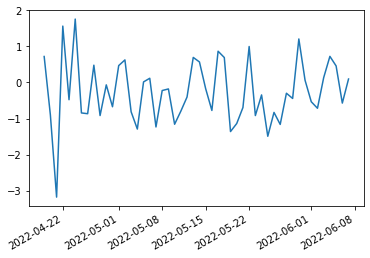

```python
# just a single line plot

pic = pd.Series(np.random.randn(50),index=pd.date_range('today',periods=50))
pic.plot()
```

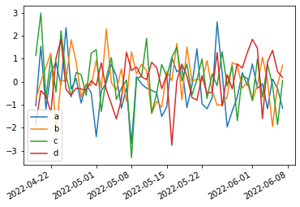

```python
pic_1 = pd.DataFrame(np.random.randn(50,4),index = pic.index,columns = ['a','b','c','d'])
pic_1.plot()
```

### To remove duplicates in a datarame

```python
df_num = pd.DataFrame({'a':[1,2,2,3,4,5,6,7,8,8,9]})
df_num
```

|  | a |
| --- | --- |
| 0 | 1 |
| 1 | 2 |
| 2 | 2 |
| 3 | 3 |
| 4 | 4 |
| 5 | 5 |
| 6 | 6 |
| 7 | 7 |
| 8 | 8 |
| 9 | 8 |
| 10 | 9 |

```python
df_num.loc[ df_num['a'].shift()!= df_num['a']]
```

|  | a |
| --- | --- |
| 0 | 1 |
| 1 | 2 |
| 3 | 3 |
| 4 | 4 |
| 5 | 5 |
| 6 | 6 |
| 7 | 7 |
| 8 | 8 |
| 10 | 9 |